# Getting Started with spectreasy

```r
suppressPackageStartupMessages(library(spectreasy))
```

# Example workflow

This vignette demonstrates the primary `spectreasy` workflow on the release-hosted example dataset. The example project contains:

- single-color controls in `scc/`
- one experimental sample in `samples/sample.fcs`

The user-facing workflow is:

1. download the example data into a project directory
2. run `unmix_controls()`
3. review and supplement the generated `fcs_mapping.csv`
4. confirm the control file in the console so `unmix_controls()` can finish
5. run `unmix_samples()`
6. generate QC reports for the controls and unmixed samples (optional)

## 1. Download the example data

`spectreasy_example_data()` downloads the example archive once, caches it under the R user cache, and can copy the extracted files into a project directory for local work.

```r
project_dir <- file.path(tempdir(), "spectreasy_vignette_project")
if (dir.exists(project_dir)) {
  unlink(project_dir, recursive = TRUE, force = TRUE)
}

example_paths <- spectreasy_example_data(dest_dir = project_dir)

list.files(project_dir, recursive = TRUE)
```

For the remainder of this vignette, the commands are shown as they would be run from the project directory created above.

Both functions receive the same output root. They create their own `unmix_controls/` and `unmix_samples/` stage directories below it.

## 2. Start the control-stage workflow

Run `unmix_controls()` first. If `fcs_mapping.csv` is missing, `auto_create_mapping = TRUE` creates it automatically and then pauses for review.

```r
setwd(project_dir)

unmix_controls(
  scc_dir = "scc",
  auto_create_mapping = TRUE,
  cytometer = "Aurora",
  auto_unknown_fluor_policy = "by_channel",
  unmixing_method = "AutoSpectral",
  unmix_scatter_panel_size_mm = 30,
  save_qc_png = TRUE
)
```

After the control file is created, `unmix_controls()` prints a confirmation prompt and waits:

```
Proceed with unmix_controls now? [y/n]:
```

## 3. Review and supplement `fcs_mapping.csv`

Open the generated `fcs_mapping.csv` in the project directory and complete the panel annotation before continuing. At minimum, review these columns:

- `fluorophore`
- `marker`
- `channel`
- `control.type`
- `is.viability`

## 4. Return to the console and confirm with `y`

Once `fcs_mapping.csv` has been reviewed and saved, return to the console where `unmix_controls()` is waiting and enter:

```
y
```

The same `unmix_controls()` call then continues and writes the control-stage outputs to `spectreasy_outputs/unmix_controls/`.

With the default `gating_mode = "interactive"`, the browser gating app opens before spectra are extracted. It lets you review the broad FSC/SSC population, singlets, and positive or negative events for each control. The resulting gate CSV can be reused for later non-interactive runs.

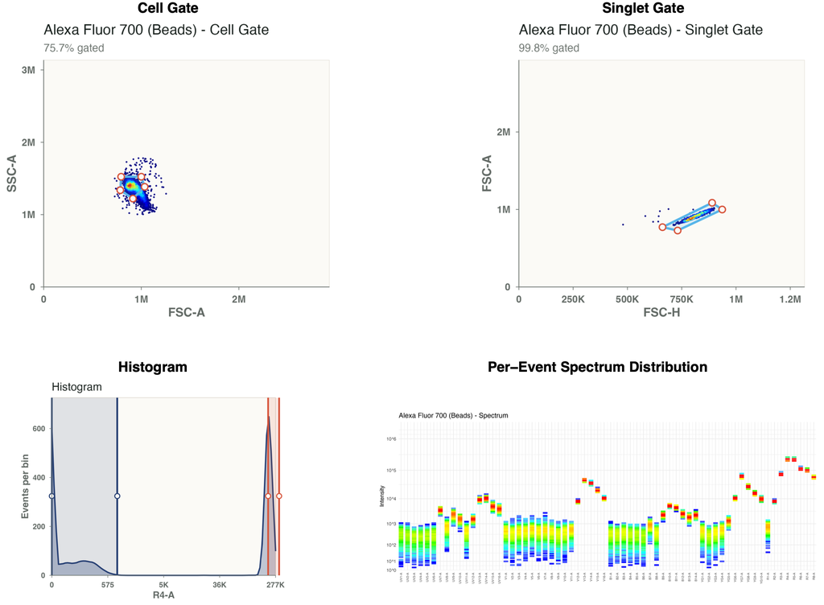

Key outputs from this step include:

- `fcs_mapping.csv`
- `spectreasy_outputs/unmix_controls/scc_detector_noise.csv`
- `spectreasy_outputs/unmix_controls/scc_reference_matrix.csv`
- `spectreasy_outputs/unmix_controls/scc_spectra.png`
- `spectreasy_outputs/unmix_controls/scc_unmixing_matrix.csv`
- `spectreasy_outputs/unmix_controls/scc_unmixing_scatter_matrix.png`
- `spectreasy_outputs/unmix_controls/fsc_ssc/*.png`
- `spectreasy_outputs/unmix_controls/histogram/*.png`
- `spectreasy_outputs/unmix_controls/spectrum/*.png`
- `spectreasy_outputs/unmix_controls/unmixed_fcs/*.fcs`

The same run creates the NxN scatter matrix for the single-color controls. Each row is one control, and each column checks how much signal appears in the other unmixed markers.

### What WLS uses

When `unmixing_method = "WLS"`, `spectreasy` uses an event-wise detector-error model: detectors with higher non-negative signal in an event get lower weight for that event. The detector noise floor is estimated from the low-signal tail of the SCC files and written to `scc_detector_noise.csv`; if no estimate is available, `spectreasy` falls back to a scalar floor of 125.

The `control.type` column in `fcs_mapping.csv` also matters here. It tells `spectreasy` whether each control should be gated as `beads` or `cells`. If `control.type` is empty, `spectreasy` falls back to filename-based guessing.

## 5. Unmix the experimental sample

After the control-stage workflow has completed, unmix the experimental files with `unmix_samples()`. The reference matrix written by `unmix_controls()` is loaded by default. The exact mapping passed to `unmix_controls(control_file = ...)` is saved beside the matrix as `fcs_mapping_used.csv` and reused for marker/fluorophore FCS labels.

```r
unmixed <- unmix_samples(
  sample_dir = "samples",
  output_dir = "spectreasy_outputs"
)
```

For the example dataset, this writes:

- `spectreasy_outputs/unmix_samples/unmixed_fcs/sample_AutoSpectral-100AF.fcs`

and returns a named list with one element per sample.

## 6. Generate quality control reports (optional)

After unmixing, you can generate comprehensive HTML reports by default to inspect the quality of both the single-color controls and the unmixed experimental samples. Use `report_format = "pdf"` for PDF output.

### Single-Color Control (SCC) Report

The SCC report reviews gating, peak channels, and signal distributions for each control file. By default, it writes the report to `"spectreasy_outputs/unmix_controls/qc_controls_report.html"`.

```r
scc_report_file <- file.path(project_dir, "spectreasy_outputs", "unmix_controls", "qc_controls_report.html")

# qc_controls(scc_dir = file.path(project_dir, "scc"), cytometer = "Aurora", seed = 1)
qc_controls(
  scc_dir = file.path(project_dir, "scc"),
  cytometer = "Aurora",
  output_file = scc_report_file,
  seed = 1
)

file.exists(scc_report_file)
```

### Samples Report

The overall sample report visualizes unmixing quality across samples, including spectra overlays, detector residuals, spread matrices, and marker scatter plots. By default, it writes the report to `"spectreasy_outputs/unmix_samples/qc_samples_report.html"`.

```r
qc_report_file <- file.path(project_dir, "spectreasy_outputs", "unmix_samples", "qc_samples_report.html")

# qc_samples(results = unmixed, M = ctrl$M)
qc_samples(
  results = unmixed,
  M = ctrl$M,
  output_file = qc_report_file
)

file.exists(qc_report_file)
```

# Optional steps

The sections below are useful extensions, but they are not required for the core `unmix_controls()` -> `unmix_samples()` workflow shown above.

## Per-cell Autofluorescence (AF) Extraction

By default, `unmix_controls()` uses `af_n_bands = 100` to choose a broad fixed AF bank from the unstained control. If your cells have different AF shapes from cell to cell, multiple AF bands can model several common AF signatures.

Use the multi-AF settings in the control-stage call. `af_n_bands` controls how many AF basis signatures are extracted from the unstained control. The default `100` is a practical starting point. Additional unstained controls in `scc/` are pooled before AF extraction.

```r
ctrl_multi_af <- unmix_controls(
  scc_dir = "scc",
  control_file = "fcs_mapping.csv",
  cytometer = "Aurora",
  output_dir = "spectreasy_outputs_multi_af",
  unmixing_method = "AutoSpectral",
  af_n_bands = 100,
  seed = 1
)
```

Then unmix samples with the control-stage matrix. AF settings stay in `unmix_controls()`; `unmix_samples()` just consumes the resulting matrix.

```r
unmixed_multi_af <- unmix_samples(
  sample_dir = "samples",
  unmixing_matrix_file = ctrl_multi_af$reference_matrix_file,
  unmixing_method = "AutoSpectral",
  output_dir = "spectreasy_outputs_multi_af"
)
```

`af_n_bands` is like choosing how many AF “flavors” to model. More bands can fit complex AF better, but too many similar bands can make the matrix unstable and slow down unmixing.

## Use a reviewed control CSV in non-interactive workflows

For scripts, reports, or CI jobs, you can supply a pre-existing, reviewed control CSV file via `control_file` to `unmix_controls()` to skip the confirmation prompt.

```r
ctrl_noninteractive <- unmix_controls(
  scc_dir = file.path(project_dir, "scc"),
  control_file = control_file,
  cytometer = "Aurora",
  output_dir = file.path(project_dir, "spectreasy_outputs_noninteractive"),
  unmixing_method = "WLS",
  gating_mode = "automatic",
  seed = 1
)

dim(ctrl_noninteractive$M)
```

## Pass the in-memory reference matrix directly

You can pass the in-memory reference matrix returned by `unmix_controls()` directly to `unmix_samples()` instead of loading it from the saved CSV file. For WLS, `unmix_samples()` will also load `scc_detector_noise.csv` beside the saved reference matrix when it is available.

```r
fluor_reference_matrix <- ctrl$M
marker_map <- stats::setNames(control_df$marker, control_df$fluorophore)
reference_matrix <- fluor_reference_matrix
mapped_names <- marker_map[rownames(reference_matrix)]
na_idx <- is.na(mapped_names)
mapped_names[na_idx] <- rownames(reference_matrix)[na_idx]
rownames(reference_matrix) <- unname(mapped_names)

unmixed_direct <- unmix_samples(
  sample_dir = file.path(project_dir, "samples"),
  M = reference_matrix,
  unmixing_method = "WLS",
  output_dir = file.path(project_dir, "spectreasy_outputs_direct")
)

names(unmixed_direct)
```

## Inspect quick QC plots

Reference spectra should be interpreted in fluorophore space, so the original fluorophore-labeled control matrix is used here.

```r
reference_matrix_no_af <- fluor_reference_matrix[!grepl("^AF($|_)", rownames(fluor_reference_matrix), ignore.case = TRUE), , drop = FALSE]

plot_spectra(reference_matrix_no_af, output_file = NULL)
```

```r
plot_nps(calculate_nps(sample_results), output_file = NULL)
```